## Production progress

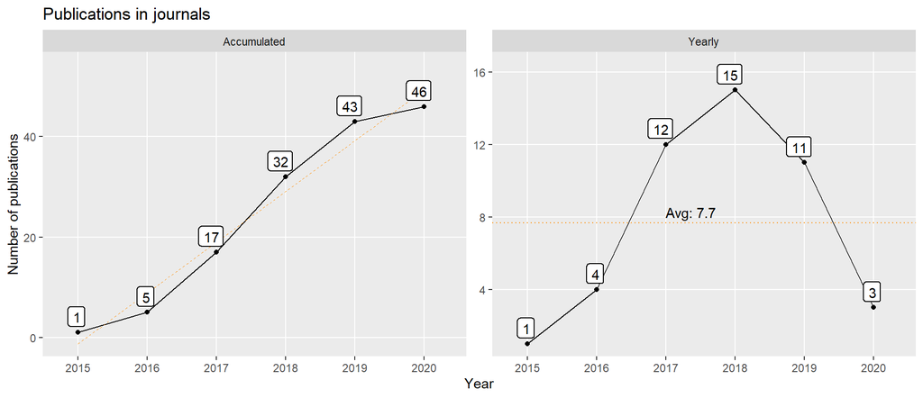

# Doctor Thesis

### Genotypic stability indexes and multivariate simultaneous selection: a new approach

[DOWNLOAD](https://www.researchgate.net/publication/339271444_Indices_de_Estabilidade_Genotipica_e_Selecao_Simultanea_Multivariada_Uma_Nova_Abordagem)

**Abstract**: In order to better understand and explore the genotype-environment interaction (GEI) in plant breeding, the development of new methods for adaptability and stability analysis, as well as the improvement of existing ones, is necessary. This study introduces the theoretical foundations, shows the numerical application and the implementation into a statistical software of new indexes for genotypic stability and multivariate simultaneous selection in plant breeding. The singular value decomposition of a two-way matrix containing the BLUPs (Best Linear Unbiased Prediction) of the GEI effects obtained in a linear mixed-effect model (LMM) was used to produce biplots useful in identifying the patterns of a random structure of GEI. A new quantitative index of genotypic stability called WAASB, based on the weighted average of the absolute value decomposition scores of the BLUPs matrix for the effects of IGA obtained in an MLM is proposed. By definition, the lower the WAASB value, the more stable a given genotype is. It is also introduced the theoretical foundations of a superiority index that allows weighting between stability (WAASB) and mean performance (Y), which was conveniently called WAASBY. The WAASBY assumes values in the range of 0−100, with 100 being assigned to the ideotype, i.e., the genotype that was most stable and that best performed on average among those considered in the test environments. A multi-trait stability index (MTSI) is used to extend the WAASB and WAASBY indexes to a multivariate structure, thus allowing selection for stability or simultaneous selection for stability and mean performance based on several traits. The application of these indexes is illustrated using real data from multi-environment trials with white oat *(Avena sativa* L.) crop. The WAASB allowed the quantification of genotypic stability and the identification of genotype groups with different patterns for stability and mean performance. Using the WAASBY index it was possible to identify genotypes that combine simultaneously high performance and yield stability. In the context of multivariate selection, positive selection differentials (SD) (1.75% ≤ SD ≤ 17.8%) were observed for trait means that wanted to increase and negative (SD = −11.7%) for one variable that wanted to reduce. The negative DS obtained for the WAASB index (−63% ≤ SD ≤ −12%) suggesting that the selected genotypes were more stable. Reliable stability measures using WAASB can help breeders and agronomists make the right decisions when selecting or recommending genotypes. Besides, the simultaneous selection index, WAASBY, will be useful when selection considers different weights for stability and mean performance. The MTSI has broad applicability in simultaneous selection for stability and mean performance based on multiple traits since it provides a unique selection process that is easy-to-handle and considers the correlation structure between traits. The proposed indices were implemented in the R metan (multi-environment trial analysis) software package. The development version of metan is available on Github https://tiagoolivoto.github.io/metan/ and can be installed directly via console R using `devtools::install_github("TiagoOlivoto/metan")`. The package metan presents a collection of functions for verifying, manipulating and summarizing typical multi-environment trial data, analyzing single-environment trials using both fixed- and mixed-effect models, computing parametric and non-parametric stability statistics, and implementing multivariate analysis.

**Keywords**: AMMI. BLUP. Genotype−environment interaction. GGE. metan.

Committee (Approved on December 19, 2019): * Prof. Dr. Alessandro Dal’Col Lúcio (Orientador) - UFSM * Prof. Dr. José Antonio Gonzales da Silva - UNIJUÍ * Prof. Dr. Sidinei José Lopes - UFSM * Prof. Dr. Thomas Newton Martin - UFSM * Prof. Dr. Velci Queiróz de Souza - UNIPAMPA